# Examen Tema 3

Se tendrá en cuenta:

- La calidad y eficiencia del código
- Ausencia de (future) warnings y errores
- La calidad visual del gráfico (ejes, estilo, etc.)
- Interpretaciones de los resultados

# Importación de librería y datos

Son datos de jugadores de la Premier League. Solamente hay datos de 3 equipos. Los datos de cada jugador son promedios de rendimiento en su club, no datos por partido.

```python
import pandas as pd
import matplotlib.pyplot as plt
import seaborn as sns


df = pd.read_csv('EPL_Soccer.csv')
print('Tamaño del dataframe', df.shape)

# muestra
df.head(5)
```

```
Tamaño del dataframe (202, 13)
```

|  | PlayerName | Club | DistanceCovered(InKms) | Goals | MinutestoGoalRatio | ShotsPerGame | AgentCharges | BMI | Cost | PreviousClubCost | Height | Weight | Score |
| --- | --- | --- | --- | --- | --- | --- | --- | --- | --- | --- | --- | --- | --- |
| 0 | Braund, Mr. Owen Harris | MUN | 3.96 | 7.5 | 37.5 | 12.3 | 60 | 20.56 | 109.1 | 63.32 | 195.9 | 78.9 | 19.75 |
| 1 | Allen, Mr. William Henry | MUN | 4.41 | 8.3 | 38.2 | 12.7 | 68 | 20.67 | 102.8 | 58.55 | 189.7 | 74.4 | 21.30 |
| 2 | Moran, Mr. James | MUN | 4.14 | 5.0 | 36.4 | 11.6 | 21 | 21.86 | 104.6 | 55.36 | 177.8 | 69.1 | 19.88 |
| 3 | McCarthy, Mr. Timothy J | MUN | 4.11 | 5.3 | 37.3 | 12.6 | 69 | 21.88 | 126.4 | 57.18 | 185.0 | 74.9 | 23.66 |
| 4 | Palsson, Master. Gosta Leonard | MUN | 4.45 | 6.8 | 41.5 | 14.0 | 29 | 18.96 | 80.3 | 53.20 | 184.6 | 64.6 | 17.64 |

### Significado de cada columna

- **PlayerName**: Nombre del jugador
- **Club**: Club del jugador. Solamente existen datos de 3 clubes.
  - MUN: Manchester United
  - CHE: Chelsea
  - LIV: Liverpool
- **DistanceCovered(InKms)**: Kilómetros promedio recorridos por el jugador en cada partido
- **Goals**: Promedio de goles por partido
- **MinutestoGoalRatio**: Minutos por gol (ratio de minutos por cada gol anotado)
- **ShotsPerGame**: Promedio de tiros por partido
- **AgentCharges**: Honorarios del agente (en cientos de euros)
- **BMI**: Índice de masa corporal
- **Cost**: Costo de cada jugador (en cientos de miles de dólares)
- **PreviousClubCost**: Costo del club anterior (en cientos de miles de dólares)
- **Height**: Altura del jugador en cm
- **Weight**: Peso del jugador en kg
- **Score**: Puntuación promedio por partido

## Ejercicio 1. Tartas (1 puntos)

Crea un gráfico de tartas para visualizar la distribución del gasto en fichajes de cada equipo (columna Cost). Se debe visualizar el % de gasto dentro de cada porción con 1 decimal.

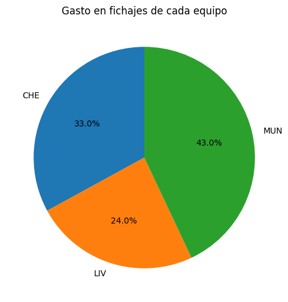

```python
gasto_fichajes = df.groupby('Club')['Cost'].sum()
# print(gasto_fichajes)

plt.figure(figsize=(6, 6))
plt.pie(
    gasto_fichajes.values,
    labels=gasto_fichajes.index,
    autopct='%1.1f%%',
    startangle=90
)
plt.title("Gasto en fichajes de cada equipo")
plt.show()
```

## Ejercicio 2. Diagrama de barras (1.5 puntos)

- Muestra en un diagrama de barras la **media** de distancia corrida 'DistanceCovered(InKms)' por cada club.
- El eje X es el nombre del club.
- El eje Y es la media de la distancia corrida por los jugadores de cada club.
- Pinta el borde de las barras de negro.
- Crea un grid de líneas horizontales.

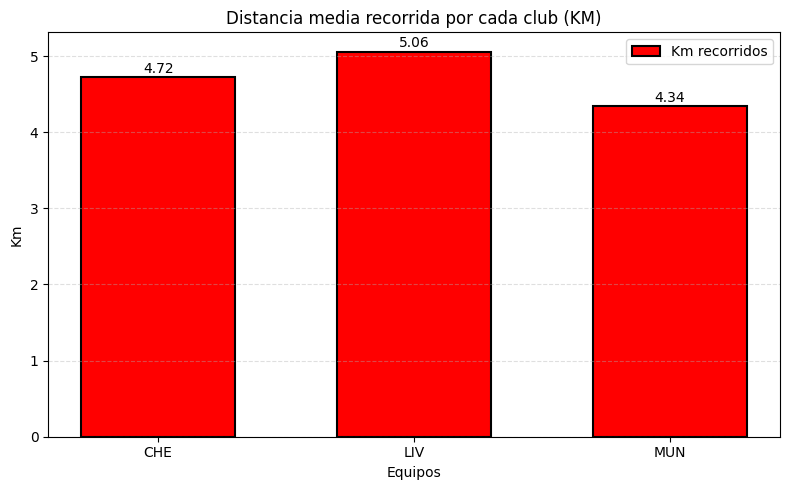

```python
distancia_media = round(df.groupby('Club')['DistanceCovered(InKms)'].mean(), 2)

fig, ax = plt.subplots(figsize=(8, 5), dpi=100)

barras = ax.bar(distancia_media.index, distancia_media.values,
                color='red',    # color del relleno
                edgecolor='black',   # color del borde
                width=0.6,          # Baras un poco más delgadas
                linewidth=1.5,      # Grosor del borde
                label='Km recorridos') # etiqueta para leyenda
ax.bar_label(barras, padding=1)
ax.set_title("Distancia media recorrida por cada club (KM)")
plt.xlabel("Equipos")
plt.ylabel("Km")

ax.grid(True, axis='y', linestyle='--', alpha=0.4) # Rejilla solo horizontal
ax.legend()

plt.tight_layout()
plt.show()
```

## Ejercicio 3. Histograma (2.5 puntos)

### Gráfica

Crea un histograma con el Score (puntuación). El histograma debe mostrar en el eje Y el número de jugadores que entran dentro de cada rango.

- Se deben crear 15 barras.
- Añade un 'grid' solamente de líneas en el eje y de estilo línea discontinua '--' y semi transparente.
- Añade a cada barra un borde negro
- Añade líneas verticales marcando la media y mediana. De estilo ':', cada una de un color diferente. Que se vea en la legenda.
- Añade un rectángulo vertical con la media +-1std.
- Se debe mostrar legenda.

### Justificación

Comenta la forma de la distribución, ¿es normal?. Basándote en la posición de la media respecto a la mediana en tu gráfico, indica si la distribución tiene sesgo (positivo o negativo) o si es simétrica. Justifica tu respuesta.

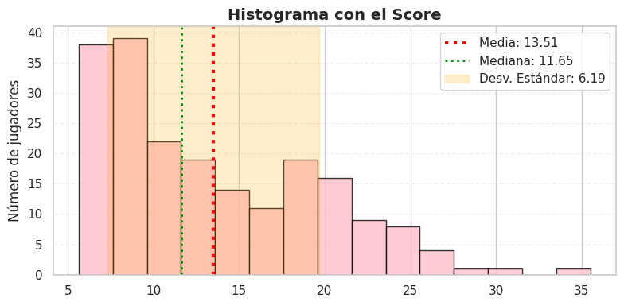

```python
score = df['Score']

media = score.mean()
mediana = score.median()
std = score.std()

fig, ax = plt.subplots(figsize=(8, 4), dpi=100)

ax.hist(score, bins=15, color='pink', edgecolor='black', alpha=0.8)

ax.set_title('Histograma con el Score', fontsize=14, fontweight='bold')
ax.set_ylabel('Número de jugadores')

ax.grid(axis='y', linestyle='--', alpha=0.3)
plt.axvline(media, color='red', linestyle='dotted', linewidth=3, label=f'Media: {media:.2f}')
plt.axvline(mediana, color='green', linestyle='dotted', linewidth=2, label=f'Mediana: {mediana:.2f}')
plt.axvspan(media - std, media + std, color='orange', alpha=0.2, label=f'Desv. Estándar: {std:.2f}')
plt.legend()

plt.tight_layout()
plt.show()

# Sesgo es hacia la derecha es decir la Media > Mediana, es decir hay valores extremadamente altos ("outliers") que están tirando
# de la media hacia arriba, aunque la mayoría de los datos sean bajos
```

## Ejercicio 4. Nube de puntos (2.5 puntos)

Cada punto en celda independiente:

#### 1. Correlación:

- Muestra la correlación entre todas las variables numéricas.
- ¿Qué 4 variables tienen más correlación (positiva o negativa) con Score?

#### 2. Gráfica:

- Muestra en un figure de 2x2 nubes de puntos de Score con cada variable de la respuesta anterior. 'Score' en el eje Y.
- Muestra el centro de la distribución con un '+' en otro color.
- Muestra un cuadro de texto en el gráfico que indique exclusivamente: "Pearson r = valor"

|  | DistanceCovered(InKms) | Goals | MinutestoGoalRatio | ShotsPerGame | AgentCharges | BMI | Cost | PreviousClubCost | Height | Weight | Score |
| --- | --- | --- | --- | --- | --- | --- | --- | --- | --- | --- | --- |
| DistanceCovered(InKms) | 1.000000 | 0.147098 | 0.924964 | 0.888800 | 0.250865 | 0.299471 | -0.403004 | 0.550975 | 0.358854 | 0.403743 | -0.493512 |
| Goals | 0.147098 | 1.000000 | 0.153333 | 0.134721 | 0.131973 | 0.177032 | 0.137131 | 0.102734 | 0.076958 | 0.155844 | 0.108114 |
| MinutestoGoalRatio | 0.924964 | 0.153333 | 1.000000 | 0.950757 | 0.258240 | 0.320527 | -0.449135 | 0.583375 | 0.371192 | 0.423699 | -0.532449 |
| ShotsPerGame | 0.888800 | 0.134721 | 0.950757 | 1.000000 | 0.308391 | 0.382524 | -0.435429 | 0.610986 | 0.352322 | 0.455255 | -0.531522 |
| AgentCharges | 0.250865 | 0.131973 | 0.258240 | 0.308391 | 1.000000 | 0.302556 | -0.108243 | 0.317581 | 0.123255 | 0.273686 | -0.183386 |
| BMI | 0.299471 | 0.177032 | 0.320527 | 0.382524 | 0.302556 | 1.000000 | 0.321116 | 0.713858 | 0.337097 | 0.845955 | 0.187558 |
| Cost | -0.403004 | 0.137131 | -0.449135 | -0.435429 | -0.108243 | 0.321116 | 1.000000 | -0.207749 | -0.071253 | 0.154227 | 0.963017 |
| PreviousClubCost | 0.550975 | 0.102734 | 0.583375 | 0.610986 | 0.317581 | 0.713858 | -0.207749 | 1.000000 | 0.802119 | 0.930904 | -0.361850 |
| Height | 0.358854 | 0.076958 | 0.371192 | 0.352322 | 0.123255 | 0.337097 | -0.071253 | 0.802119 | 1.000000 | 0.780906 | -0.188022 |
| Weight | 0.403743 | 0.155844 | 0.423699 | 0.455255 | 0.273686 | 0.845955 | 0.154227 | 0.930904 | 0.780906 | 1.000000 | -0.000162 |
| Score | -0.493512 | 0.108114 | -0.532449 | -0.531522 | -0.183386 | 0.187558 | 0.963017 | -0.361850 | -0.188022 | -0.000162 | 1.000000 |

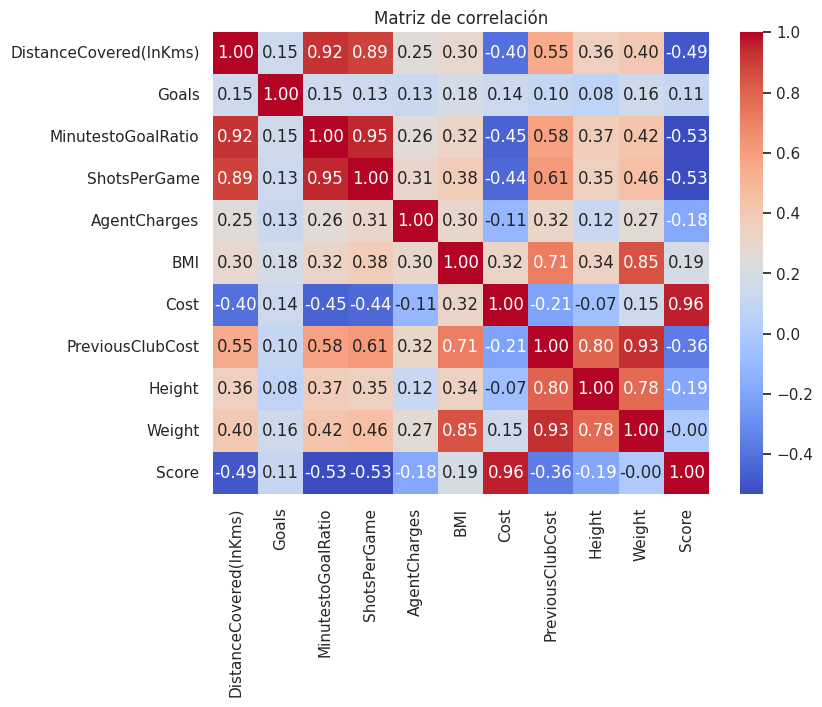

```python
numericas_df = df.select_dtypes(include=['int64', 'float64'])
corr_matrix = numericas_df.corr()
display(corr_matrix)

# Las 4 variables que tienen más correlación con Score son:
# DistanceCovered(InKms), MinutestoGoalRatio, ShotsPerGame, Cost
plt.figure(figsize=(8, 6))
sns.set_theme(style="whitegrid")
sns.heatmap(corr_matrix, annot=True, cmap='coolwarm', fmt='.2f')
plt.title("Matriz de correlación")
plt.show()
```

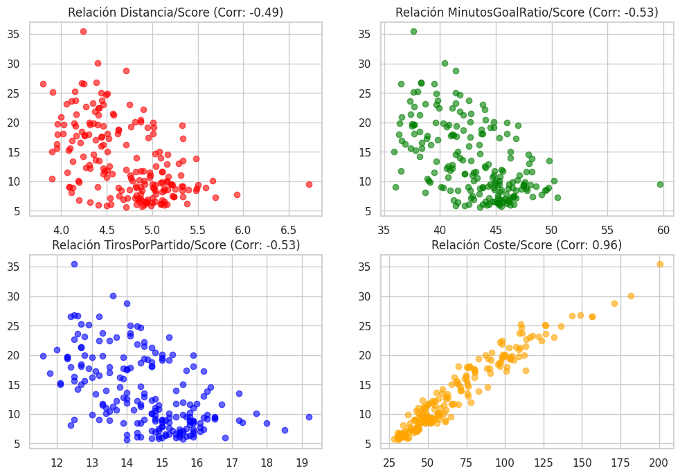

```python
# corr = df['Score'].corr(method="pearson")
fig, axes = plt.subplots(2, 2, figsize=(12, 8), dpi=100)

axes[0, 0].scatter(df['DistanceCovered(InKms)'], df['Score'],  color='red', alpha=0.6)
axes[0, 0].set_title(f"Relación Distancia/Score (Corr: {df['Score'].corr(df['DistanceCovered(InKms)']):.2f})")

axes[0, 1].scatter(df['MinutestoGoalRatio'], df['Score'],  color='green', alpha=0.6)
axes[0, 1].set_title(f"Relación MinutosGoalRatio/Score (Corr: {df['Score'].corr(df['MinutestoGoalRatio']):.2f})")

axes[1, 0].scatter(df['ShotsPerGame'], df['Score'],  color='blue', alpha=0.6)
axes[1, 0].set_title(f"Relación TirosPorPartido/Score (Corr: {df['Score'].corr(df['ShotsPerGame']):.2f})")

axes[1, 1].scatter(df['Cost'], df['Score'],  color='orange', alpha=0.6)
axes[1, 1].set_title(f"Relación Coste/Score (Corr: {df['Score'].corr(df['Cost']):.2f})")
```

## Ejercicio 5: Boxplot (2.5 puntos)

#### Gráfica:

- Crea un boxplot de cajas verticales donde el eje Y es el Score y el eje X es el club.
- Pinta una línea de estilo '--' en color rojo con la media de puntuación total (que se vea en legenda).

#### Justificaciones y otros

- Calcula el IQR de cada box y el límite para considerar outliers de cada equipo.
- Muestra los jugadores de cada equipo que son outliers.
- Compara las cajas: qué equipo tiene mayor mediana, en dónde hay más variablidad o dispersión.

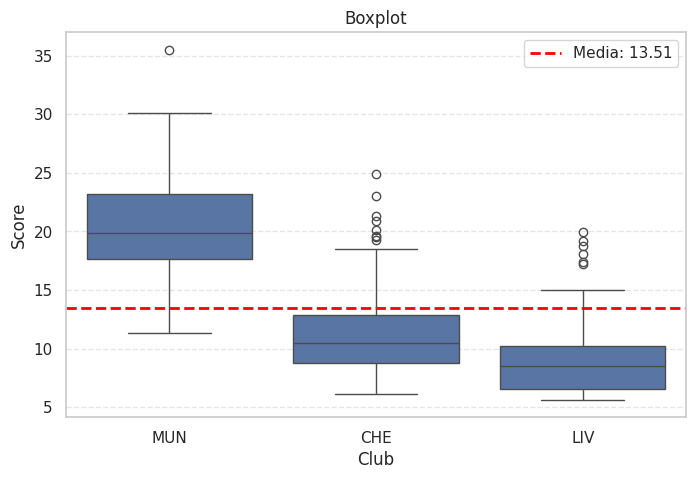

```python
media = df['Score'].mean()

fig, ax = plt.subplots(figsize=(8, 5))
sns.boxplot(x=df['Club'], y=df['Score'])
ax.set_title('Boxplot')

ax.grid(axis='y', linestyle='--', alpha=0.5)
plt.axhline(media, color='red', linestyle='dashed', linewidth=2, label=f'Media: {media:.2f}')
plt.legend()

plt.show()
```

```python
outliers_info = []

for club, jugadores in df.groupby('Club'):

    q1 = jugadores['Score'].quantile(0.25)
    q3 = jugadores['Score'].quantile(0.75)

    iqr = q3 - q1

    limite_sup = q3 + 1.5 * iqr

    n_outliers = (jugadores['Score'] > limite_sup).sum()

    outliers_info.append({
        "Club": club,
        "Límite superior": limite_sup,
        "Nº Outliers": n_outliers,
        "Media": jugadores['Score'].mean(),
        "Mediana": jugadores['Score'].median(),
        "Std": jugadores['Score'].std()
    })

outliers_df = pd.DataFrame(outliers_info)

outliers_df
```

|  | Club | Límite superior | Nº Outliers | Media | Mediana | Std |
| --- | --- | --- | --- | --- | --- | --- |
| 0 | CHE | 19.020 | 8 | 11.614744 | 10.505 | 4.192483 |
| 1 | LIV | 15.785 | 6 | 9.417692 | 8.510 | 3.763284 |
| 2 | MUN | 31.500 | 1 | 20.515254 | 19.830 | 4.505214 |